# OpenIntro Statistics in Python

## Lab 0: Introduction to Pandas and IPython

This lab guide assumes two things:

1. a (very) basic familiarity with Python and the command line, but no more than that.
2. that you have installed the [Anaconda distribution](http://docs.continuum.io/anaconda/) of Python for your computer. The dependencies for Python's scientific computing stack are complicated and this is the easiest option to get up-and-running.

## Installing Pandas and IPython in a virtual environment

To make sure that this lab guide works on your computer, and to allow you to keep modules in one Python project separate from those in another, we will create a 'virtual environment' using Anaconda. This creates a safe laboratory space in which you can install whatever packages you find useful for statistical analysis, without worrying that these will break something elsewhere.

Open a command prompt or terminal and create a virtual environment called `openintrolabs` by using this command:

```
conda create -n openintrolabs python=3.4
```

This has created a fresh Python 3 installation for us - and because it is enclosed in a virtual environment, this won't affect any existing Python 2 projects you may have.

Now enter this environment by using the following command if you are using Windows:

```
activate openintrolabs
```

Or, if you are using a Linux distribution:

```
source activate openintrolabs
```

When a virtual environment is activated, its name prepended to your terminal prompt. Like this in Windows:

[figure not shown]

Or like this in Linux:

[figure not shown]

You can exit a virtual environment by using the command `deactivate`. You can try that now but, afterwards, reactivate the openintrolabs environment with `activate openintrolabs` (or `source activate openintrolabs` on Linux) so that we can carry on with the Lab.

Now let's install a few packages into our base Python environment:

- Pandas, a data analysis toolkit.
- Matplotlib, for plotting.
- Statsmodels, for statistical function.
- IPython, for creating interactive notebooks

Make sure you are in your openintrolabs virtual environment and enter these commands:

```
conda install pandas
conda install ipython-notebook
conda install matplotlib
conda install statsmodels
```

We should now have a working environment for data analysis. Let's get started!

## Getting started with Pandas and IPython

We'll conduct our data analysis in IPython 'notebooks'. As the name suggests, you can *write* in IPython notebooks, but you can also use them to execute Python code and display visualizations or other graphics. They are a powerful tool for data exploration and statistical analysis.

Start the notebook server by, first, navigating to a convenient working folder on the command line and then executing the following command in your virtual environment. (After doing so, you will need to keep the terminal running as you work.)

```
ipython notebook
```

After a few seconds, your browser should open a new tab like this:

[figure not shown]

Create a notebook by clicking 'new' in the top right-hand corner and then selecting 'Python 3' under 'Notebooks'. This will open a new tab which contains a notebook, ready for us to work in.

[figure not shown]

At the top of the screen 'Untitled' is the name of our notebook. We can change this by clicking on it.

The white rectange labelled `In [ ]:` is a cell. A cell is where we enter code or text.

More cells can be added with the + button on the toolbar and cells can be rearranged with the up and down arrows.

The cell input type (code or Markdown text) can be changed using the dropdown menu that is set to 'Code' by default.

Click into the first cell, change the type to Markdown and enter the following text:

```python
# Getting started with Pandas and IPython
```

Press **shift and enter** to run this cell. The `#` is Markdown code for a large heading and so IPython renders this text as a nice big title for our notebook.

Now let's run some Python code and get started with data analysis.

Input these lines into the first cell after your heading and run the cell:

```python
import pandas as pd
%matplotlib inline
```

These lines import pandas, the data analysis library and, by convention, rename it to pd. Now when we call pandas functions, we will call pd. It saves us four whole keystrokes.

The second line tells IPython to draw graphs in the notebook itself rather than creating separate windows each time.

## Reading data into Pandas

We can now start working with data. In a new cell enter and execute the following code:

```python
present_url = 'https://github.com/ScatteredInk/OpenIntro-Python-Labs/raw/master/Lab0/present.csv'

present = pd.read_csv(present_url)

present.head()
```

|  | year | boys | girls |
| --- | --- | --- | --- |
| 0 | 1940 | 1211684 | 1148715 |
| 1 | 1941 | 1289734 | 1223693 |
| 2 | 1942 | 1444365 | 1364631 |
| 3 | 1943 | 1508959 | 1427901 |
| 4 | 1944 | 1435301 | 1359499 |

This code may take a few seconds to execute as it is instructing Pandas to open a CSV file located on the internet and store this in the variable `present`. When the file has downloaded, the `head()` function instructs Pandas to display the first few rows of the data.

## Present Data

The present data set refers to the number of male and female births in the United States. The data set contains the data for all years from 1940 to 2002. We can take a look at the data by typing the variable name into a cell and executing.

```python
present
```

What you should see are four columns of numbers, each row representing a different year: the first entry in each row is simply the row number (an index we can use to access the data from individual years if we want), the second is the year, and the third and fourth are the numbers of boys and girls born that year, respectively. Use the scrollbar on the right side of the console window to examine the head and tail of this data set. A row of ellipses represents the middle of this data, removed from this summary view.

Note that the row numbers in the first column are not part of the present data set. Pandas adds them as part of its data model. You can think of them as the index that you see on the left side of a spreadsheet. In fact, the comparison to a spreadsheet will generally be helpful. Pandas has stored the data in a kind of spreadsheet or table called a **DataFrame**.

You can see the dimensions of this DataFrame by typing:

```python
present.shape
```

```
(63, 3)
```

The output (63, 3) indicates that there are 63 rows and 3 columns. You can see the names of these columns by typing:

```python
present.columns.tolist()
```

```
['year', 'boys', 'girls']
```

### Question 1

How many variables are included in this data set?:

- A) 2
- B) 3
- C) 4
- D) 63
- E) 2002

## Some Exploration

Let’s start to examine the data a little more closely. We can access the data in a single column of a data frame separately using a command like

This command will only show the number of boys born each year.

```python
present['boys']
```

```
0     1211684
1     1289734
2     1444365
3     1508959
4     1435301
5     1404587
6     1691220
7     1899876
8     1813852
9     1826352
10    1823555
11    1923020
12    1971262
13    2001798
14    2059068
```

[output cut: 17 more lines]

### Question 2

What command would you use to extract just the counts of girls births?

- A) `present['girls']`
- B) `present['boys']`
- C) `girls`
- D) `present[girls]`
- E) `'girls'`

We can see that present and the columns of present are different data types by inputting the following commands:

```python
type(present)
```

```
pandas.core.frame.DataFrame
```

```python
type(present['boys'])
```

```
pandas.core.series.Series
```

## Visualizing data

Pandas has some powerful functions for making graphics. To make these easier to use, we will set the **index** of our DataFrame to the 'year' column of our dataset. This is makes more sense than the arbitrary 0 to 62 numbering that we had before.

```python
present.set_index('year', inplace=True)
```

Have a look at the `present` DataFrame with the following commands.

```python
present.head()
```

| year | boys | girls |
| --- | --- | --- |
| 1940 | 1211684 | 1148715 |
| 1941 | 1289734 | 1223693 |
| 1942 | 1444365 | 1364631 |
| 1943 | 1508959 | 1427901 |
| 1944 | 1435301 | 1359499 |

```python
present.tail()
```

| year | boys | girls |
| --- | --- | --- |
| 1998 | 2016205 | 1925348 |
| 1999 | 2026854 | 1932563 |
| 2000 | 2076969 | 1981845 |
| 2001 | 2057922 | 1968011 |
| 2002 | 2057979 | 1963747 |

Our index is now the years 1940 through 2002. The same index is also applied to the individual Series that make up the DataFrame.

```python
present['boys'].head()
```

```
year
1940    1211684
1941    1289734
1942    1444365
1943    1508959
1944    1435301
Name: boys, dtype: int64
```

We can plot the number of girls born per year with the following command.

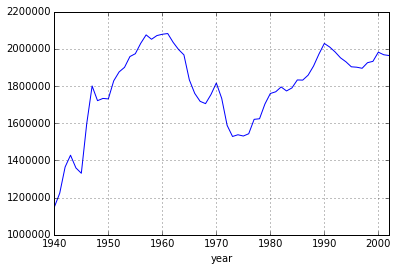

```python
present['girls'].plot()
```

To add a legend to this plot, the command is `present['girls'].plot(legend=True)`. You might wonder how you are supposed to know that it was possible to add that argument. Thankfully, the Pandas documention is available online and can also be accessed from within IPython. To read what a function does and learn the arguments that are available to you, just type in a question mark before or after the name of the function that you’re interested in: `pd.DataFrame.plot?`.

### Question 3

Is there an apparent trend in the number of girls born over the years? How would you describe it?

- A) There appears to be no trend in the number of girls born from 1940 to 2002.
- B) There is initially an increase in the number of girls born, which peaks around 1960. After 1960 there is a decrease in the number of girls born, but the number begins to increase again in the early 1970s. Overall the trend is an increase in the number of girls born in the US since the 1940s.
- C) There is initially an increase in the number of girls born. This number peaks around 1960 and then after 1960 the number of girls born decreases.
- D) The number of girls born has decreased over time.
- E) There is an initial increase in the number of girls born but this number appears to level around 1960 and not change since then.

Now, suppose we want to plot the total number of births. To compute this, we could use the fact that IPython is really just a big calculator. We can type in mathematical expressions like

```python
1211684 + 1148715
```

```
2360399
```

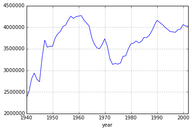

```python
combined_births = present['boys'] + present['girls']
combined_births.plot()
```

In the above expression we create a new Series object, assign it to `combined_births` and then call the plot function for Series objects.

## Finding minima and maxima

We can see a summary of our DataFrame, including the minimum and maximum values in each column, with the describe() function.

```python
present.describe()
```

|  | boys | girls |
| --- | --- | --- |
| count | 63.000000 | 63.000000 |
| mean | 1885599.619048 | 1793915.015873 |
| std | 226511.422927 | 218559.840911 |
| min | 1211684.000000 | 1148715.000000 |
| 25% | 1799857.000000 | 1711404.500000 |
| 50% | 1924868.000000 | 1831679.000000 |
| 75% | 2058523.500000 | 1965537.500000 |
| max | 2186274.000000 | 2082052.000000 |

But how do we *when* these minimum or maximum values occured? To do this we can use the idxmin() and idxmax() functions, which give us the index values at the min or max. The code to find the year when the most number of girls were born is:

```python
present['girls'].idxmax()
```

```
1961
```

### Question 4

In what year did we see the most total number of births in the U.S.? Use the `combined_births` variable we have already created and the functions just introduced to answer this question.

- A) 1961
- B) 1960
- C) 1957
- D) 1991

```python
1211684/1148715
```

```
1.0548169041058921
```

```python
present['boys'] / present['girls']
```

The proportion of newborns that were boys in 1940 can be calculated with:

```python
1211684 / (1211684 + 1148715)
```

```
0.5133386346969305
```

Or this may also be calculated for all years simultaneously:

```python
present['boys'] / (present['boys'] + present['girls'])
```

Note that with IPython, as with your calculator, you need to be conscious of the order of operations. Here, we want to divide the number of boys by the total number of newborns, so we have to use parentheses. Without them, Python will first do the division, then the addition, giving you something that is not a proportion.

### Question 5

Now, create a new variable containing the proportion of boys over time, plot this Series, and based on the plot determine if the following statement is true or false: The proportion of boys born in the US has decreased over time.

- True
- False

Finally, in addition to simple mathematical operators like subtraction and division, you can ask Pandas to make comparisons like greater than, `>`, less than, `<`, and equality, `==`. For example, we can ask if boys outnumber girls in each year with the expression:

```python
present['boys'] > present['girls']
```

This command returns a Series of 63 boolean values. The value is either True if that year had more boys than girls, or False if that year did not. This output shows a different kind of data than we have considered so far. In the DataFrame our values are numerical (the year, the number of boys and girls). Here, we’ve asked Pandas to create logical data, data where the values are either True or False. In general, data analysis will involve many different kinds of data types, and one reason for using Pandas is that it is able to represent and compute with many of them.

One way of quickly analysing boolean data is with the value_counts function. This returns an object containing counts of unique values in a Series.

```python
(present['boys'] > present['girls']).value_counts()
```

### Question 6

Which statesment is true?

- A) Every year there are more girls born than boys.
- B) Every year there are more boys born than girls.
- C) Half of the years there are more boys born, and the other half more girls born.

Now try to answer the following questions without additional guidance on the coding, based on what you have learned so far.

### Question 7

Make a plot that displays the boy-to-girl ratio for every year in the data set. What do you see?

- A) There appears to be no trend in the boy-to-girl ratio from 1940 to 2002.
- B) There is initially an increase in boy-to-girl ratio, which peaks around 1960. After 1960 there is a decrease in the boy-to-girl ratio, but the number begins to increase in the mid 1970s.
- C) There is initially a decrease in the boy-to-girl ratio, and then an increase between 1960 and 1970, followed by a decrease.
- D) The boy-to-girl ratio has increased over time.
- E) There is an initial decrease in the boy-to-girl ratio born but this number appears to level around 1960 and remain constant since then.

### Question 8

Calculate absolute differences between number of boys and girls born in each year, and determine which year out of the present data had the biggest absolute difference in the number of girls and number of boys born?

- A) 1963
- B) 1946
- C) 2002
- D) 1940

These data come from a [report](http://www.cdc.gov/nchs/data/nvsr/nvsr53/nvsr53_20.pdf) by the Centers for Disease Control. Check it out if you would like to read more about an analysis of sex ratios at birth in the United States.

This lab was adapted for Python Pandas by Jack Lord from the original OpenIntro product. The source code is on [Github](https://github.com/ScatteredInk/OpenIntro-Python-Labs). It is released under a Creative Commons Attribution-ShareAlike 3.0 Unported license. The original lab was adapted for OpenIntro by Andrew Bray and Mine Çetinkaya-Rundel from a lab written by Mark Hansen of UCLA Statistics.

```python
from IPython.core.display import HTML
def css_styling():
    styles = open("./styles/custom.css", "r").read()
    return HTML(styles)
css_styling()
```